# Lake Water Quality Analysis

Daniel Cleveland

2/28/2022

# LAGOS Analysis

## Loading in data

### First download and then specifically grab the locus (or site lat longs)

```r
#Lagos download script
#lagosne_get(dest_folder = LAGOSNE:::lagos_path(),overwrite=T)

#Load in lagos
lagos <- lagosne_load()


#Grab the lake centroid info
lake_centers <- lagos$locus

# Make an sf object
spatial_lakes <- st_as_sf(lake_centers,coords=c('nhd_long','nhd_lat'),
                          crs=4326)

#Grab the water quality data
nutr <- lagos$epi_nutr

#Look at column names
#names(nutr)
```

### Subset columns nutr to only keep key info that we want

```r
clarity_only <- nutr %>%
  select(lagoslakeid,sampledate,chla,doc,secchi) %>%
  mutate(sampledate = as.character(sampledate) %>% ymd(.))
```

### Keep sites with at least 200 observations

```r
#Look at the number of rows of dataset
#nrow(clarity_only)

chla_secchi <- clarity_only %>%
  filter(!is.na(chla),
         !is.na(secchi))

# How many observatiosn did we lose?
# nrow(clarity_only) - nrow(chla_secchi)


# Keep only the lakes with at least 200 observations of secchi and chla
chla_secchi_200 <- chla_secchi %>%
  group_by(lagoslakeid) %>%
  dplyr::mutate(count = n()) %>%
  filter(count > 200)
```

### Join water quality data to spatial data

```r
spatial_200 <- inner_join(spatial_lakes,chla_secchi_200 %>%
                            distinct(lagoslakeid,.keep_all=T),
                          by='lagoslakeid')
```

### Mean Chl_a map

```r
### Take the mean chl_a and secchi by lake

mean_values_200 <- chla_secchi_200 %>%
  # Take summary by lake id
  dplyr::group_by(lagoslakeid) %>%
  # take mean chl_a per lake id
  dplyr::summarize(mean_chl = mean(chla,na.rm=T),
            mean_secchi=mean(secchi,na.rm=T)) %>%
  #Get rid of NAs
  dplyr::filter(!is.na(mean_chl),
         !is.na(mean_secchi)) %>%
  # Take the log base 10 of the mean_chl
  dplyr::mutate(log10_mean_chl = log10(mean_chl))

#Join datasets
mean_spatial <- inner_join(spatial_lakes,mean_values_200,
                          by='lagoslakeid')

#Make a map
mapview(mean_spatial,zcol='log10_mean_chl')
```

[interactive chart not shown]

# Class work

### 1) What is the correlation between Secchi Disk Depth and Chlorophyll a for sites with at least 200 observations?

- Here, I just want a plot of chla vs secchi for all sites

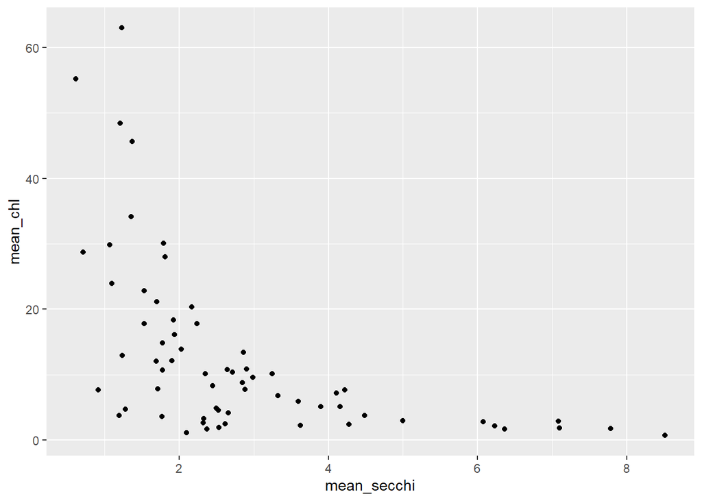

```r
# creating simple scatter plot

ggplot2::ggplot(mean_values_200, aes(x = mean_secchi, y = mean_chl)) +
  geom_point()
```

The deeper the mean_secchi value, the lower the mean_chl value. This relationship appears logarithmic as well.

#### Why might this be the case?

It makes sense that as nutrient loads in the water increases, the higher the chlorophyll a content will be, and the less-clear the water becomes. As the water becomes less clear, the depth at which the secchi disk disappears becomes shallower.

### 2) What states have the most data?

*The student assumes this means the most chla and secchi combined data, only. Therefore the student does not factor in the doc data.*

#### 2a) First you will need to make a lagos spatial dataset that has the total number of counts per site.

```r
chla_secchi_all <- clarity_only %>%
  filter(!is.na(chla),
         !is.na(secchi))%>%
         #!is.na(doc))%>%
  group_by(lagoslakeid) %>%
  dplyr::mutate(COUNT = n()) %>%
  arrange(desc(COUNT))
```

#### 2b) Second, you will need to join this point dataset to the us_boundaries data.

```r
## Your code here
all_states <- us_states()


## Taking only lakes that are within the US States:
us_lakes <- spatial_lakes[all_states,]

## Joining us_lakes to chla_secchi_all
### Keeping all of the chla and secchi data and adding the lake centroid to each lagoslakeid observation:
chla_secchi_all_us <- left_join(chla_secchi_all,us_lakes,
                                     by = 'lagoslakeid',
                                     keep = FALSE)
```

```r
## converting data to spatial data
spatial_wq_us <- st_as_sf(chla_secchi_all_us,
                          crs = 4326)
```

```r
## Joining spatial_chla_secchi_all to all_states by geometry
chla_secchi_all_by_state <- st_join(spatial_wq_us, all_states,
                                    join = st_intersects)
```

#### 2c) Then you will want to group by state and sum all the observations in that state and arrange that data from most to least total observations per state.

```r
## grouping, counting, and arranging by count:
wq_by_state <- chla_secchi_all_by_state %>%
                      group_by(state_abbr)%>%
                      summarise(tot_obsv = n())%>%
                      arrange(-tot_obsv)%>%
                      filter(!is.na(state_abbr))

## getting rid of geometry column
cleaned_obs <- st_set_geometry(wq_by_state, NULL)
```

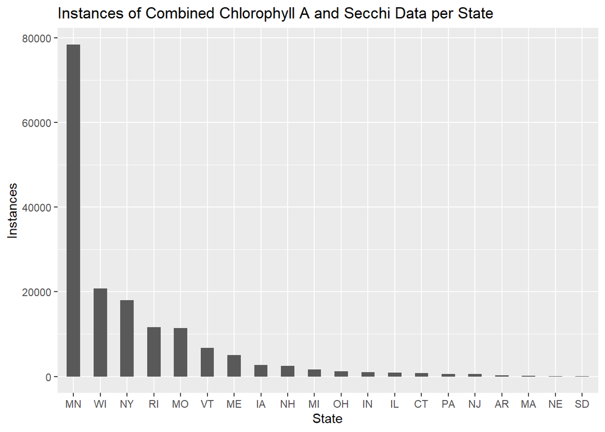

```r
## plotting observations for comparison:
ggplot(cleaned_obs,
       aes(x = reorder(state_abbr,-tot_obsv),y = tot_obsv)) +
  geom_bar(stat="identity", width=0.5)+
  xlab("State")+
  ylab("Instances") +
  ggtitle("Instances of Combined Chlorophyll A and Secchi Data per State")
```

As can be seen in the above bar chart, Minnesota has the highest number of instances of combined secchi and chlorophyll a data, followed by Wisconsin and then New York.

### 3) Is there a spatial pattern in Secchi disk depth for lakes with at least 200 observations?

#### *Student assumes that this question is trying to ask, “Looking at a map of mean Secchi disk depth values of lakes having more than 200 Secchi disk depth measurements, can we detect a spatial pattern in mean Secchi disk depth?”*

*(This assumption is based on lack of available unique geometry data for each individual secchi observation, and shear number of lakes having more than 200 Secchi observations)*

*Also, student assumes that whether or not site has chla data is irrelevant for this question.*

```r
## filtering nutr down to only lakes with 200+ secchi observations, ...
## ...and  selecting only lakeid, secchi, and observations columns...

sdd_only <- nutr %>%
  select(lagoslakeid,secchi)%>%
  filter(!is.na(secchi))%>%
  group_by(lagoslakeid)%>%
  mutate(lake_obsv = n())%>%
  filter(lake_obsv > 200)%>%
  arrange(-lake_obsv)
```

```r
## getting mean secchi disk depths for each lake id
sdd_means <- sdd_only %>%
                        group_by(lagoslakeid)%>%
                        summarise(sdd_mean = mean(secchi))
```

```r
##cleaning spatial lakes down to lagoslakeid and geometry:
sp_lakes_cln <- spatial_lakes %>%
                        select(lagoslakeid)


##joining geometry onto the sdd means by lagoslakeid:
sdd_means_geo <- left_join(sdd_means,sp_lakes_cln,
                          by = 'lagoslakeid',
                          keep = FALSE)

## converting sdd_means_geo to spatial object:
sdd_plot <- st_as_sf(sdd_means_geo, crs=4326)
```

```r
##  mapping the mean secchi disk depth values for all lakes having over 200 observations of secchi disk depth.

mapview(sdd_plot, zcol = 'sdd_mean')
```

[interactive chart not shown]

As can be seen by the map of mean secchi disk depths for lakes having over 200 secchi observations, the disk depths tend to be deepest in the Northeast United States. The secchi disk depths tend to become shallower as the lake locations move further west.